# Ford GoBike System Data

## Preliminary Wrangling

> This data set includes information about individual rides made in a bike-sharing system covering the greater San Francisco Bay area in year 2017. The source data (Ford GoBike System Data) is available at : https://www.fordgobike.com/system-data.

```python
# import all packages and set plots to be embedded inline
import numpy as np
import pandas as pd
import matplotlib.pyplot as plt
import seaborn as sns

%matplotlib inline
```

> Load in your dataset and describe its properties through the questions below. Try and motivate your exploration goals through this section.

```python
bikeshare_data = pd.read_csv('2017-fordgobike-tripdata.csv')
```

```python
bikeshare_data.head()
```

|  | duration_sec | start_time | end_time | start_station_id | start_station_name | start_station_latitude | start_station_longitude | end_station_id | end_station_name | end_station_latitude | end_station_longitude | bike_id | user_type |
| --- | --- | --- | --- | --- | --- | --- | --- | --- | --- | --- | --- | --- | --- |
| 0 | 80110 | 2017-12-31 16:57:39.6540 | 2018-01-01 15:12:50.2450 | 74 | Laguna St at Hayes St | 37.776435 | -122.426244 | 43 | San Francisco Public Library (Grove St at Hyde... | 37.778768 | -122.415929 | 96 | Customer |
| 1 | 78800 | 2017-12-31 15:56:34.8420 | 2018-01-01 13:49:55.6170 | 284 | Yerba Buena Center for the Arts (Howard St at ... | 37.784872 | -122.400876 | 96 | Dolores St at 15th St | 37.766210 | -122.426614 | 88 | Customer |
| 2 | 45768 | 2017-12-31 22:45:48.4110 | 2018-01-01 11:28:36.8830 | 245 | Downtown Berkeley BART | 37.870348 | -122.267764 | 245 | Downtown Berkeley BART | 37.870348 | -122.267764 | 1094 | Customer |
| 3 | 62172 | 2017-12-31 17:31:10.6360 | 2018-01-01 10:47:23.5310 | 60 | 8th St at Ringold St | 37.774520 | -122.409449 | 5 | Powell St BART Station (Market St at 5th St) | 37.783899 | -122.408445 | 2831 | Customer |
| 4 | 43603 | 2017-12-31 14:23:14.0010 | 2018-01-01 02:29:57.5710 | 239 | Bancroft Way at Telegraph Ave | 37.868813 | -122.258764 | 247 | Fulton St at Bancroft Way | 37.867789 | -122.265896 | 3167 | Subscriber |

```python
bikeshare_data.info()
```

```
<class 'pandas.core.frame.DataFrame'>
RangeIndex: 519700 entries, 0 to 519699
Data columns (total 13 columns):
 #   Column                   Non-Null Count   Dtype
---  ------                   --------------   -----
 0   duration_sec             519700 non-null  int64
 1   start_time               519700 non-null  object
 2   end_time                 519700 non-null  object
 3   start_station_id         519700 non-null  int64
 4   start_station_name       519700 non-null  object
 5   start_station_latitude   519700 non-null  float64
 6   start_station_longitude  519700 non-null  float64
 7   end_station_id           519700 non-null  int64
 8   end_station_name         519700 non-null  object
 9   end_station_latitude     519700 non-null  float64
 10  end_station_longitude    519700 non-null  float64
 11  bike_id                  519700 non-null  int64
 12  user_type                519700 non-null  object
dtypes: float64(4), int64(4), object(5)
memory usage: 51.5+ MB
```

```python
# Extract month, day, hour information
bikeshare_data['start_time'] =  pd.to_datetime(bikeshare_data['start_time'])
bikeshare_data['month'] = bikeshare_data.start_time.dt.month
bikeshare_data['weekday'] = bikeshare_data.start_time.dt.weekday
bikeshare_data['hour'] = bikeshare_data.start_time.dt.hour
```

```python
bikeshare_data.sample()
```

|  | duration_sec | start_time | end_time | start_station_id | start_station_name | start_station_latitude | start_station_longitude | end_station_id | end_station_name | end_station_latitude | end_station_longitude | bike_id | user_type | month | weekday | hour |
| --- | --- | --- | --- | --- | --- | --- | --- | --- | --- | --- | --- | --- | --- | --- | --- | --- |
| 289556 | 1310 | 2017-10-01 16:35:45.428 | 2017-10-01 16:57:35.6580 | 10 | Washington St at Kearny St | 37.795393 | -122.40477 | 15 | San Francisco Ferry Building (Harry Bridges Pl... | 37.795392 | -122.394203 | 2202 | Customer | 10 | 6 | 16 |

```python
bikeshare_data_clean = bikeshare_data.copy()
```

### What is the structure of your dataset?

> This dataset contains 519700 entries with (13+3) columns. Orignally, each entry contains information regarding duration time, start/end stations, and user type (customer or subscriber), etc. In order to extract month, weekday and hour information, we first convert `start_time` column to a datetime format, we then apply `dt` accessor to the `start_time` column to extract detailed date information and store them in 3 new columns, respectively.

### What is/are the main feature(s) of interest in your dataset?

> - Bike usage by hour of day, day of week, and month of year.
> - Comparisons of usage between customers and subscribers.
> - Duration of rides
> - Station Usage patterns at Peak Hours

### What features in the dataset do you think will help support your investigation into your feature(s) of interest?

> - `duration_sec` column, which provides info regarding the ride duration time.
> - `user_type` column, which informs the bike user is a customer or a subscriber.
> - `month`, `weekday`, `hour` columns, which provide info regarding bike usage time.
> - `start_station_latitude` and `start_station_longitude` columns informs the location of the bike station

## Univariate Exploration

> In this section, we investigate distributions of individual variables.

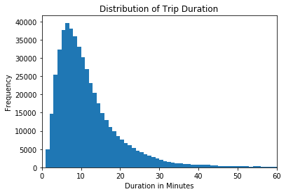

```python
# Distribution of the trip duration
bikeshare_data_clean['duration_min'] = bikeshare_data['duration_sec']/60
bins = np.arange(0, bikeshare_data_clean['duration_min'].max() + 1 , 1)

fig, ax = plt.subplots()
ax.hist(data = bikeshare_data_clean , x = 'duration_min', bins = bins)
ax.set_xlim(0,60)
ax.set_title('Distribution of Trip Duration')
ax.set_xlabel('Duration in Minutes')
ax.set_ylabel('Frequency');
```

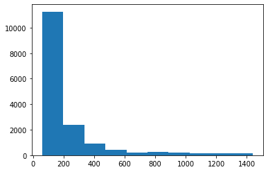

```python
bikeshare_data_longtime= bikeshare_data_clean[bikeshare_data_clean['duration_min']>60]
plt.hist(data = bikeshare_data_longtime,x='duration_min');
```

Also, we notice that there are outliers with a riding time longer than 1 hour. This happens when the users didn't return the bike after using them, but instead keeing for themselves for using next time. Or, some users use the shared bike for a long-distance bike trip. Since the main goal of the shared bike is to help people commute within the city, we will not further consider the users with "irrational" behaviors.

```python
bikeshare_data_clean = bikeshare_data_clean[bikeshare_data_clean['duration_min']<=60]
bikeshare_data_clean.to_csv('bikeshare_sf.csv',index=False)
```

## Bivariate Exploration

> In this section, we move to bivariate exploration. In the following, we investigate:
- Bike usage by month
- Bike usage by weekday
- Bike usage by hour
- Trip durations by month

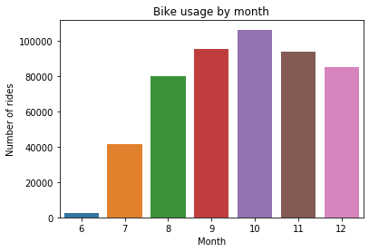

```python
ax = sns.countplot(x="month",data=bikeshare_data_clean)
ax.set_title('Bike usage by month')
ax.set_xlabel('Month')
ax.set_ylabel('Number of rides');
```

Here we can see that people ride the most in October. Towards winter or summer time, the number of rides decreases. The reason behind this riding behavior may be that autumn time has the most comfortable temperature for riding. While for winter or summer time, the weather gets either cold or hot, making it not very pleasent to ride outside. This observation is especially evident in summer time, e.g., July. However, also notice that the number of rides is especially low in June compared with other months. Considering the current table only contains the information regarding the latter half of the year, it may happen that data inaccuracy issue occurs at the intersection of two consecutive tables. This issue deserves further investigation, together with the data preparation and collection team.

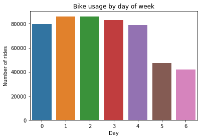

```python
ax = sns.countplot(x="weekday",data=bikeshare_data_clean)
ax.set_title('Bike usage by day of week')
ax.set_xlabel('Day')
ax.set_ylabel('Number of rides')
```

Here we can see that shared bikes were mostly used in workdays. Number of rides in weekends reduced around half compared with the weekdays' data. This observation indicates that people use shared bike mainly for commuting between home and work place.

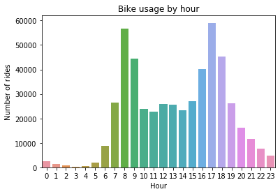

```python
ax = sns.countplot(x="hour",data=bikeshare_data_clean)
ax.set_title('Bike usage by hour')
ax.set_ylabel('Number of rides')
ax.set_xlabel('Hour');
```

This figure further comfirms the conclusion we made earlier. Bike usage by hour shows itself as a binominal distribution, with one mode at around 8am and another mode at arounf 17pm. Those times correspond to the morning and afternoon rush hour when people commute between home and work place.

Next, we investigate the relationship between the trip duration and the month when users ride. For that purpose, we start by a boxplot, with x-axis being the month and y-axis being the trip duration.

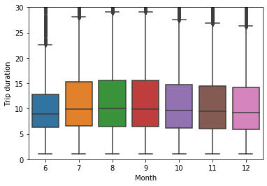

```python
ax = sns.boxplot(x="month", y="duration_min", data=bikeshare_data_clean)
ax.set_ylim(0,30)
ax.set_xlabel('Month')
ax.set_ylabel('Trip duration');
```

Here we can see that there is basically no distinction of trip duration among different months: except for June when not enough data was collected, the median, 25\% and 75\% quantiles of the trip duration are almost the same for different months. This is probably due to the fact that San Francisco does not have distinct four seasons. As a result, month factor does not affect trip duration that much.

To ovisualize the whole distribution instead of just summary statistics, we further compare the ridge plot for displaying the full distribution of trip duration at each month.

```python
def label(x, color, label):
    ax = plt.gca()
    ax.text(-0.1, .2, label, fontweight="bold", color="black",
            ha="left", va="center", transform=ax.transAxes)
```

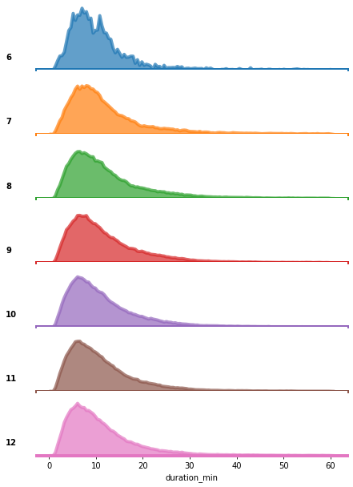

```python
# Use FacetGrid to create the facet with one column
ridge_plot = sns.FacetGrid(bikeshare_data_clean, row="month", hue="month", aspect=5, height=1.25)

# Use map function to make density plot in each element of the grid.
ridge_plot.map(sns.kdeplot, "duration_min", clip_on=False, shade=True, alpha=0.7, lw=4, bw=.2)
ridge_plot.map(plt.axhline, y=0, lw=4, clip_on=False)
ridge_plot.map(label, "duration_min")
# Set the subplots to overlap
ridge_plot.fig.subplots_adjust(hspace=-0.01)
# Remove axes details that don't play well with overlap
ridge_plot.set_titles("")
ridge_plot.set(yticks=[])
ridge_plot.despine(bottom=True, left=True);
```

The above figure further confirms that the trip duration pattern stays the same for various months.

## Multivariate Exploration

> In this section, we first investigate whether a user is a customer or a subscriber will make a difference in terms of trip duration. Later on, we investigate bike station usage patterns during peak hours (8am & 17pm).

### Impact of user type

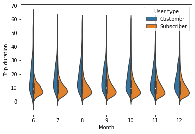

```python
ax = sns.violinplot(x="month", y="duration_min", hue="user_type",data=bikeshare_data_clean,split=True)
ax.set_xlabel('Month')
ax.set_ylabel('Trip duration')
ax.legend(title= 'User type');
```

Here we can see that subscribers tend to rider shorter time compared with single-time users.

### Map display

In this section, we investigate the bike station usage patterns at peak hours of the weekdays. Peak hours are 8am and 17pm, according to what we observed in the figure "bike usage by hour". Here we are looking for further evidence that people mainly use shared bike to commute between home and workplace. To make the investigation more focused, we only look at bike stations within San Francisco city.

`start_station_latitude`, `start_station_longitude`, `end_station_latitude` and `end_station_longitude` column provide coordinates of the bike stations, which we can plot in the form of a map. In addition, in order to further enhance the visualization, we will retrieve the actual map of San Francisco and use it as the base map. In this way, we can better appreciate the spatial connections between bike stations and easily find interesting usage patterns.

To begin with, we display all the active stations in San Francisco in the map. We achieve this goal in three steps:

- First of all, we import `contextily` and `pyproj` package for downloading maps and transforming geo-coordinates, respectively. We only retain the entries within weekdays, and perform coordinate transformation to convert GPS coordinates to X/Y web mercator coordinates. The newly converted coordinates are stored in four new columns `start_X`, `start_Y`, `end_X` and `end_Y`.

```python
# Import pakages for downloading maps and transforming geo-coordinates
import contextily as cx
from pyproj import Proj, transform

# Only retain usage info during weekdays
stations = bikeshare_data_clean.query('weekday<5').reset_index()

# Convert geo-coordinates, from GPS to x/y web mercator
inProj, outProj = Proj(init='epsg:4326'), Proj(init='epsg:3857')
stations['start_X'], stations['start_Y'] = transform(inProj, outProj, stations['start_station_longitude'].tolist(),
                             stations['start_station_latitude'].tolist())
stations['end_X'], stations['end_Y'] = transform(inProj, outProj, stations['end_station_longitude'].tolist(),
                             stations['end_station_latitude'].tolist())
```

- Second, we employ `contextily` package to download the city map of San Francisco.

```python
# Download map (San Francisco city)
west, south, east, north = (-122.461049,37.74116,-122.376935,37.816608)
sf_img, sf_ext = cx.bounds2img(west,south,east,north,ll=True,
                               source=cx.providers.Wikimedia,
                               zoom=14)
```

- Finally, we plot the downloaded map and make a scatter plot of bike stations on top of the map.

[figure not shown]

```python
f, ax = plt.subplots(1, figsize=(7, 7))

ax.imshow(sf_img, extent=sf_ext)
ax.scatter(stations.start_X,stations.start_Y,marker='o',c='g',s=30)
ax.set_xlim(sf_ext[0:2])
ax.set_ylim(sf_ext[2:])
ax.set_title('Bike stations in San Francisco',fontsize=16)
ax.set_yticklabels([])
ax.set_xticklabels([]);
```

```python
def trip_selection(df,time,trip):
    '''Extract desired station usage information'''
    # Columns to retain
    column_list = [trip + s for s in ['_station_id','_X','_Y']]

    # Slice input DataFrame
    station = df.query('hour==@time').loc[:,column_list].reset_index(drop=True)

    # Counts station usage info
    station_usage = station[column_list[0]].value_counts().rename_axis(column_list[0]).reset_index(name='counts')

    # Drop duplicated stations
    station.drop_duplicates(subset=column_list[0],inplace=True)

    # Merge two datasets
    station = station.merge(station_usage,left_on=column_list[0], right_on=column_list[0])

    return station
```

```python
# Extract usage info at 8am & 5pm
sf_am = [trip_selection(stations,8,'start'),trip_selection(stations,8,'end')]
sf_pm = [trip_selection(stations,17,'start'),trip_selection(stations,17,'end')]
```

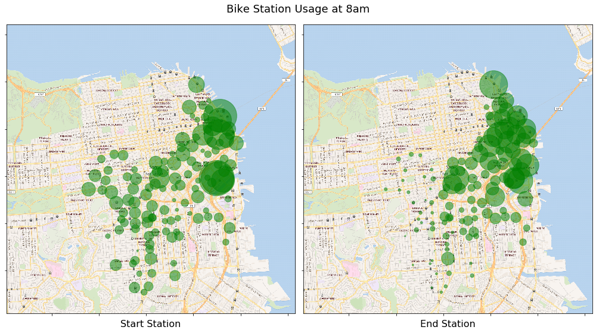

```python
# Display patterns in the morning
f, axs = plt.subplots(1,2, figsize=(14, 14))
trip = ['Start Station','End Station']

for i,ax in enumerate(axs):
    # Display map
    ax.imshow(sf_img, extent=sf_ext)
    # Display bike stations
    ax.scatter(sf_am[i].iloc[:,1],sf_am[i].iloc[:,2],c='g',s=sf_am[i].iloc[:,3],alpha=0.5)
    ax.set_xlim(sf_ext[0:2])
    ax.set_ylim(sf_ext[2:])
    ax.set_yticklabels([])
    ax.set_xticklabels([])
    ax.set_xlabel(trip[i],fontsize=16)

f.suptitle('Bike Station Usage at 8am',fontsize=18)
f.tight_layout()
f.subplots_adjust(top=1.4)
```

At 8am, we can see that a lot of rides start near BART transit stations (Bay Area Rapid Transit). Especially high volumes of rides (indicated by the bigger green dots) are started at ferry dock and at the end of Caltrain station. In terms of the ending locations, we can see that a large number of rides end in downtown San Francisco (Financial District). At 17pm, the opposite trend can be observed that many rides start at business centers and end at BART transit stations, Caltrain station and ferry stop. Therefore, we can conclude that people use public transportations to commute from outside of the city and use shard bikes to commute from major transit terminals to their workplaces.

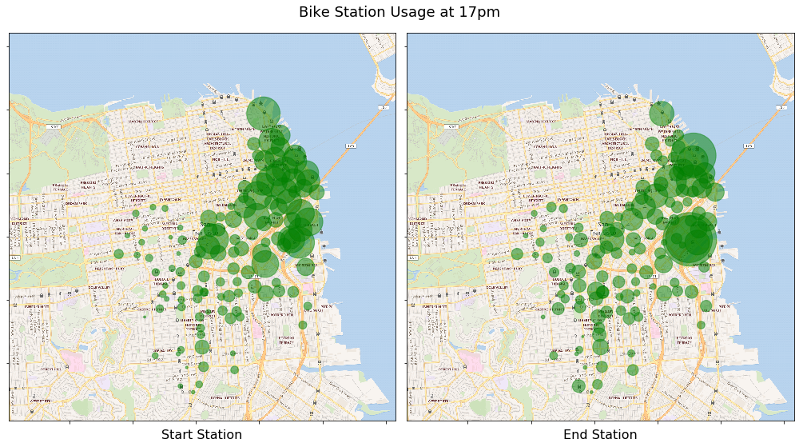

```python
# Display patterns in the afternoon
f, axs = plt.subplots(1,2, figsize=(14, 14))
trip = ['Start Station','End Station']

for i,ax in enumerate(axs):
    # Display map
    ax.imshow(sf_img, extent=sf_ext)
    # Display bike stations
    ax.scatter(sf_pm[i].iloc[:,1],sf_pm[i].iloc[:,2],c='g',s=sf_pm[i].iloc[:,3],alpha=0.5)
    ax.set_xlim(sf_ext[0:2])
    ax.set_ylim(sf_ext[2:])
    ax.set_yticklabels([])
    ax.set_xticklabels([])
    ax.set_xlabel(trip[i],fontsize=16)

f.suptitle('Bike Station Usage at 17pm',fontsize=18)
f.tight_layout()
f.subplots_adjust(top=1.4)
```

## Questions:

My original intention was to download a railway map of San Francisco and overlay with the bike station scatter plot. However, when I try to download the map from OpenRailwayMap, I got the following warning message. Later when I plot the figure, the backgroud is all black, instead of being transparent. Obvisouly the visualization quality is very bad. I would like to know how to solve this problem? I tried several methods but none of them worked.

```python
# Acquire transportation map (San Francisco city)
west, south, east, north = (-122.461049,37.74116,-122.376935,37.816608)
sf_img, sf_ext = cx.bounds2img(west,south,east,north,ll=True,
                               source=cx.providers.OpenRailwayMap,
                               zoom=14)
```

```
C:\Users\Shuai\Anaconda3\lib\site-packages\PIL\Image.py:932: UserWarning: Palette images with Transparency expressed in bytes should be converted to RGBA images
  "Palette images with Transparency expressed in bytes should be "
```

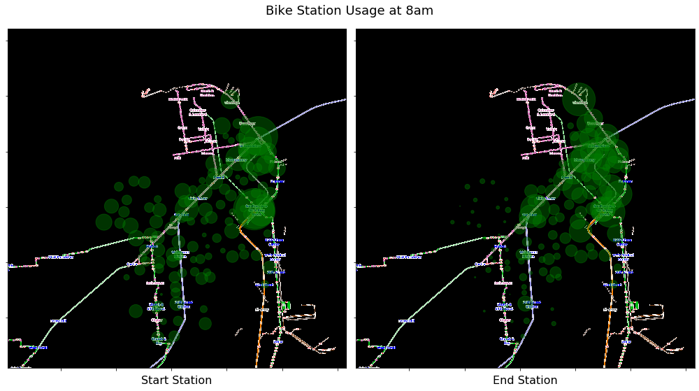

```python
# Display patterns in the morning
f, axs = plt.subplots(1,2, figsize=(14, 14))
trip = ['Start Station','End Station']

for i,ax in enumerate(axs):
    # Display map
    ax.imshow(sf_img, extent=sf_ext)
    # Display bike stations
    ax.scatter(sf_am[i].iloc[:,1],sf_am[i].iloc[:,2],c='g',s=sf_am[i].iloc[:,3],alpha=0.4)
    ax.set_xlim(sf_ext[0:2])
    ax.set_ylim(sf_ext[2:])
    ax.set_yticklabels([])
    ax.set_xticklabels([])
    ax.set_xlabel(trip[i],fontsize=16)

f.suptitle('Bike Station Usage at 8am',fontsize=18)
f.tight_layout()
f.subplots_adjust(top=1.4)
```